# 10 Model effectiveness

# Goal

Now that we have about a year’s worth of additional data I’d like to investigate the effectiveness or ROI of the model by looking at different metrics associated with outcomes during the out-of-sample period. Some ideas:

- Giving (direct measure)
- Visits (indirect measure)
- Qualifications/disqualifications (indirect measure)

# Libraries

```r
library(tidyverse)
library(ggplot2)
```

# Visit data

I created a SQL query (roi-visit-outcomes.sql) to look at people who were reached out to specifically for qualification purposes in the last two years.

```r
visits <- readxl::read_xlsx(
  path = 'data/2019-07-23 qualifications data.xlsx'
  , sheet = 'With'
)
# Add some helpful indicators
visits <- visits %>% mutate(
  # Only outreach since the model data year
  qual = CFY_QUALIFICATION + PFY1_QUALIFICATION > 0
  , qual_EXCL_VISIT = CFY_QUALIFICATION_EXCL_VISIT + PFY1_QUALIFICATION_EXCL_VISIT > 0
  , outreach = CFY_OUTREACH + PFY1_OUTREACH > 0
  , visit = CFY_VISITS + PFY1_VISITS + PFY2_VISITS > 0
  , scored = !is.na(PR_SCORE)
  , never_visited = is.na(FIRST_VISIT_FY)
  , fy19_first_visit = !never_visited & FIRST_VISIT_FY == 2019
)
```

```r
rbind(
  Total.contacted = visits %>% nrow()
  , With.PR.score = visits %>% filter(scored) %>% nrow()
  , Never.visited = visits %>% filter(never_visited) %>% nrow()
  , FY19.first.visit = visits %>% filter(fy19_first_visit) %>% nrow()
)
```

```
                  [,1]
Total.contacted  20624
With.PR.score     5278
Never.visited    11734
FY19.first.visit  1348
```

```r
rbind(
  With.outreach = visits %>% filter(scored & outreach) %>% nrow()
  , With.qual = visits %>% filter(scored & outreach) %>% filter(qual_EXCL_VISIT) %>% nrow()
  , With.outreach.visit = visits %>% filter(scored & outreach & visit) %>% nrow()
  , With.qual.visit = visits %>% filter(scored & qual_EXCL_VISIT & visit) %>% nrow()
)
```

```
                    [,1]
With.outreach       4102
With.qual           4055
With.outreach.visit  930
With.qual.visit     1117
```

```r
visits_first_potential <- visits %>% filter(scored) %>% filter(fy19_first_visit | never_visited)
rbind(
  With.outreach = visits_first_potential %>% filter(outreach) %>% nrow()
  , With.qual = visits_first_potential %>% filter(qual_EXCL_VISIT) %>% nrow()
  , With.outreach.visit = visits_first_potential %>% filter(outreach & visit) %>% nrow()
  , With.qual.visit = visits_first_potential %>% filter(qual_EXCL_VISIT & visit) %>% nrow()
)
```

```
                    [,1]
With.outreach       2415
With.qual           2986
With.outreach.visit  189
With.qual.visit      240
```

This is more than enough first-time visits for an analysis. Begin by looking at qualification counts and visit outcomes by PR score.

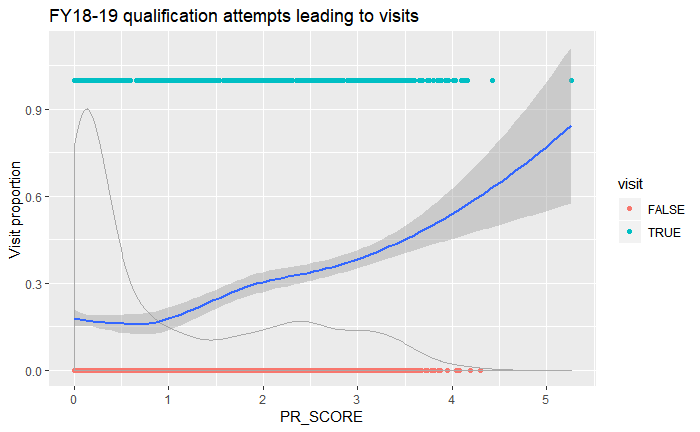

```r
visits %>%
  # Only people with qualification attempts
  filter(scored & qual_EXCL_VISIT) %>%
  # Must have had non-visit qualification attempts last year
  filter(PFY1_QUALIFICATION_EXCL_VISIT > 0) %>%
  ggplot(aes(x = PR_SCORE)) +
  geom_point(aes(color = visit, y = as.numeric(visit))) +
  geom_density(color = 'darkgray') +
  geom_smooth(aes(y = as.numeric(visit)), method = 'loess') +
  labs(y = 'Visit proportion', title = 'FY18-19 qualification attempts leading to visits')
```

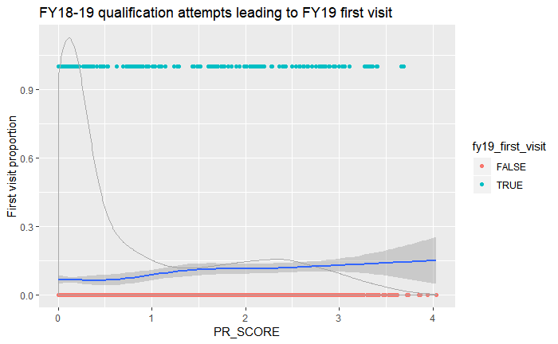

```r
visits_first_potential %>%
  # Only people with qualification attempts in the last couple years
  filter(qual_EXCL_VISIT | outreach) %>%
  ggplot(aes(x = PR_SCORE)) +
  geom_point(aes(color = fy19_first_visit, y = as.numeric(visit))) +
  geom_density(color = 'darkgray') +
  geom_smooth(aes(y = as.numeric(visit)), method = 'loess') +
  labs(y = 'First visit proportion', title = 'FY18-19 qualification attempts leading to FY19 first visit')
```

So that’s somewhat promising.

# FY19 visit status predictions

Start by looking at people who took first visits this year based on last year’s outreach.

```r
model <- visits_first_potential %>% glm(
  fy19_first_visit ~
    PR_SCORE +
    ID_SCORE +
    log10(EVALUATION_LOWER_BOUND + 1) +
    sqrt(PFY1_QUALIFICATION_EXCL_VISIT) +
    sqrt(PFY2_QUALIFICATION_EXCL_VISIT) +
    sqrt(PFY3_QUALIFICATION_EXCL_VISIT) +
    sqrt(PFY1_OUTREACH) +
    sqrt(PFY2_OUTREACH) +
    sqrt(PFY3_OUTREACH) +
    sqrt(PFY1_EMAIL) +
    sqrt(PFY2_EMAIL) +
    sqrt(PFY3_EMAIL) +
    sqrt(PFY1_PHONE) +
    sqrt(PFY2_PHONE) +
    sqrt(PFY3_PHONE) +
    PROGRAM_GROUP
  , data = .
)
summary(model)
```

```
Call:
glm(formula = fy19_first_visit ~ PR_SCORE + ID_SCORE + log10(EVALUATION_LOWER_BOUND +
    1) + sqrt(PFY1_QUALIFICATION_EXCL_VISIT) + sqrt(PFY2_QUALIFICATION_EXCL_VISIT) +
    sqrt(PFY3_QUALIFICATION_EXCL_VISIT) + sqrt(PFY1_OUTREACH) +
    sqrt(PFY2_OUTREACH) + sqrt(PFY3_OUTREACH) + sqrt(PFY1_EMAIL) +
    sqrt(PFY2_EMAIL) + sqrt(PFY3_EMAIL) + sqrt(PFY1_PHONE) +
    sqrt(PFY2_PHONE) + sqrt(PFY3_PHONE) + PROGRAM_GROUP, data = .)

Deviance Residuals:
     Min        1Q    Median        3Q       Max
-0.31429  -0.09354  -0.05624  -0.02869   1.01341

Coefficients:
                                     Estimate Std. Error t value Pr(>|t|)
(Intercept)                         -0.011309   0.095144  -0.119   0.9054
PR_SCORE                             0.014065   0.010533   1.335   0.1820
ID_SCORE                             0.060891   0.027298   2.231   0.0259 *
log10(EVALUATION_LOWER_BOUND + 1)   -0.007430   0.013320  -0.558   0.5771
sqrt(PFY1_QUALIFICATION_EXCL_VISIT) -0.046519   0.025544  -1.821   0.0689 .
sqrt(PFY2_QUALIFICATION_EXCL_VISIT)  0.007100   0.033248   0.214   0.8309
sqrt(PFY3_QUALIFICATION_EXCL_VISIT) -0.052989   0.036215  -1.463   0.1437
sqrt(PFY1_OUTREACH)                  0.013179   0.024024   0.549   0.5834
sqrt(PFY2_OUTREACH)                 -0.013821   0.033632  -0.411   0.6812
sqrt(PFY3_OUTREACH)                  0.035285   0.036776   0.959   0.3375
sqrt(PFY1_EMAIL)                     0.015242   0.017312   0.880   0.3788
sqrt(PFY2_EMAIL)                     0.018196   0.022481   0.809   0.4185
sqrt(PFY3_EMAIL)                    -0.001096   0.023563  -0.047   0.9629
sqrt(PFY1_PHONE)                     0.038923   0.049994   0.779   0.4364
sqrt(PFY2_PHONE)                    -0.031745   0.062747  -0.506   0.6130
sqrt(PFY3_PHONE)                     0.122053   0.065692   1.858   0.0634 .
PROGRAM_GROUPEXECED                 -0.052568   0.129947  -0.405   0.6859
PROGRAM_GROUPFT                     -0.030213   0.023925  -1.263   0.2069
PROGRAM_GROUPPHD                    -0.108511   0.149208  -0.727   0.4672
PROGRAM_GROUPTMP                    -0.022545   0.029149  -0.773   0.4394
PROGRAM_GROUPUNK                    -0.060179   0.256465  -0.235   0.8145
---
Signif. codes:  0 *** 0.001 ** 0.01 * 0.05 . 0.1   1

(Dispersion parameter for gaussian family taken to be 0.0650586)

    Null deviance: 72.408  on 1087  degrees of freedom
Residual deviance: 69.418  on 1067  degrees of freedom
  (1949 observations deleted due to missingness)
AIC: 137.48

Number of Fisher Scoring iterations: 2
```

Or combining years:

```r
model_b <- visits_first_potential %>% mutate(
  ALLPFY_QUAL_EXCL_VISIT = PFY1_QUALIFICATION_EXCL_VISIT + PFY2_QUALIFICATION_EXCL_VISIT + PFY3_QUALIFICATION_EXCL_VISIT
) %>% glm(
  fy19_first_visit ~
    PR_SCORE +
    ID_SCORE +
    log10(EVALUATION_LOWER_BOUND + 1) +
    sqrt(ALLPFY_QUAL_EXCL_VISIT) +
    sqrt(PFY1_OUTREACH + PFY2_OUTREACH + PFY3_OUTREACH) +
    sqrt(PFY1_EMAIL + PFY2_EMAIL + PFY3_EMAIL) +
    sqrt(PFY1_PHONE + PFY2_PHONE + PFY3_PHONE) +
    PROGRAM_GROUP
  , data = .
)
summary(model_b)
```

```
Call:
glm(formula = fy19_first_visit ~ PR_SCORE + ID_SCORE + log10(EVALUATION_LOWER_BOUND +
    1) + sqrt(ALLPFY_QUAL_EXCL_VISIT) + sqrt(PFY1_OUTREACH +
    PFY2_OUTREACH + PFY3_OUTREACH) + sqrt(PFY1_EMAIL + PFY2_EMAIL +
    PFY3_EMAIL) + sqrt(PFY1_PHONE + PFY2_PHONE + PFY3_PHONE) +
    PROGRAM_GROUP, data = .)

Deviance Residuals:
     Min        1Q    Median        3Q       Max
-0.23276  -0.09279  -0.05560  -0.02850   1.00817

Coefficients:
                                                     Estimate Std. Error t value Pr(>|t|)
(Intercept)                                         -0.013083   0.093876  -0.139   0.8892
PR_SCORE                                             0.014232   0.010499   1.356   0.1755
ID_SCORE                                             0.066084   0.026933   2.454   0.0143 *
log10(EVALUATION_LOWER_BOUND + 1)                   -0.008106   0.013215  -0.613   0.5397
sqrt(ALLPFY_QUAL_EXCL_VISIT)                        -0.044874   0.023643  -1.898   0.0580 .
sqrt(PFY1_OUTREACH + PFY2_OUTREACH + PFY3_OUTREACH)  0.007472   0.021266   0.351   0.7254
sqrt(PFY1_EMAIL + PFY2_EMAIL + PFY3_EMAIL)           0.010252   0.013743   0.746   0.4558
sqrt(PFY1_PHONE + PFY2_PHONE + PFY3_PHONE)           0.038630   0.033783   1.143   0.2531
PROGRAM_GROUPEXECED                                 -0.040487   0.129701  -0.312   0.7550
PROGRAM_GROUPFT                                     -0.028139   0.023715  -1.187   0.2357
PROGRAM_GROUPPHD                                    -0.109194   0.148951  -0.733   0.4637
PROGRAM_GROUPTMP                                    -0.019504   0.029024  -0.672   0.5017
PROGRAM_GROUPUNK                                    -0.063048   0.256109  -0.246   0.8056
---
Signif. codes:  0 *** 0.001 ** 0.01 * 0.05 . 0.1   1

(Dispersion parameter for gaussian family taken to be 0.06491718)

    Null deviance: 72.408  on 1087  degrees of freedom
Residual deviance: 69.786  on 1075  degrees of freedom
  (1949 observations deleted due to missingness)
AIC: 127.24

Number of Fisher Scoring iterations: 2
```

Compare this to just using PR score.

```r
update(model_b, formula = . ~ . - ID_SCORE, data = visits_first_potential %>% mutate(
  ALLPFY_QUAL_EXCL_VISIT = PFY1_QUALIFICATION_EXCL_VISIT + PFY2_QUALIFICATION_EXCL_VISIT + PFY3_QUALIFICATION_EXCL_VISIT
)) %>% summary()
```

```
Call:
glm(formula = fy19_first_visit ~ PR_SCORE + log10(EVALUATION_LOWER_BOUND +
    1) + sqrt(ALLPFY_QUAL_EXCL_VISIT) + sqrt(PFY1_OUTREACH +
    PFY2_OUTREACH + PFY3_OUTREACH) + sqrt(PFY1_EMAIL + PFY2_EMAIL +
    PFY3_EMAIL) + sqrt(PFY1_PHONE + PFY2_PHONE + PFY3_PHONE) +
    PROGRAM_GROUP, data = visits_first_potential %>% mutate(ALLPFY_QUAL_EXCL_VISIT = PFY1_QUALIFICATION_EXCL_VISIT +
    PFY2_QUALIFICATION_EXCL_VISIT + PFY3_QUALIFICATION_EXCL_VISIT))

Deviance Residuals:
     Min        1Q    Median        3Q       Max
-0.22215  -0.09030  -0.05432  -0.03285   0.99773

Coefficients:
                                                     Estimate Std. Error t value Pr(>|t|)
(Intercept)                                          0.132543   0.072905   1.818   0.0693 .
PR_SCORE                                             0.031542   0.007794   4.047 5.56e-05 ***
log10(EVALUATION_LOWER_BOUND + 1)                   -0.005031   0.013186  -0.382   0.7029
sqrt(ALLPFY_QUAL_EXCL_VISIT)                        -0.053119   0.023457  -2.265   0.0237 *
sqrt(PFY1_OUTREACH + PFY2_OUTREACH + PFY3_OUTREACH)  0.016263   0.021011   0.774   0.4391
sqrt(PFY1_EMAIL + PFY2_EMAIL + PFY3_EMAIL)           0.017659   0.013438   1.314   0.1891
sqrt(PFY1_PHONE + PFY2_PHONE + PFY3_PHONE)           0.044198   0.033786   1.308   0.1911
PROGRAM_GROUPEXECED                                 -0.066151   0.129580  -0.511   0.6098
PROGRAM_GROUPFT                                     -0.030501   0.023751  -1.284   0.1993
PROGRAM_GROUPPHD                                    -0.115083   0.149279  -0.771   0.4409
PROGRAM_GROUPTMP                                    -0.024017   0.029034  -0.827   0.4083
PROGRAM_GROUPUNK                                    -0.075075   0.256659  -0.293   0.7700
---
Signif. codes:  0 *** 0.001 ** 0.01 * 0.05 . 0.1   1

(Dispersion parameter for gaussian family taken to be 0.06522007)

    Null deviance: 72.408  on 1087  degrees of freedom
Residual deviance: 70.177  on 1076  degrees of freedom
  (1949 observations deleted due to missingness)
AIC: 131.32

Number of Fisher Scoring iterations: 2
```

Interesting; ID_SCORE is far and away the best predictor of visits. Presumably PR score turns out to be too similar. let’s look at visit proportion by ID score instead of PR score.

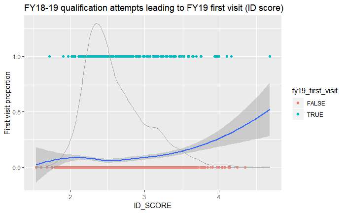

```r
visits_first_potential %>%
  # Only people with qualification attempts in the last couple years
  filter(qual_EXCL_VISIT | outreach) %>%
  ggplot(aes(x = ID_SCORE)) +
  geom_point(aes(y = as.numeric(fy19_first_visit), color = fy19_first_visit)) +
  geom_density(color = 'darkgray') +
  geom_smooth(aes(y = as.numeric(fy19_first_visit)), method = 'loess') +
  labs(y = 'First visit proportion', title = 'FY18-19 qualification attempts leading to FY19 first visit (ID score)')
```

Or looking at only the ID_score below 4.5:

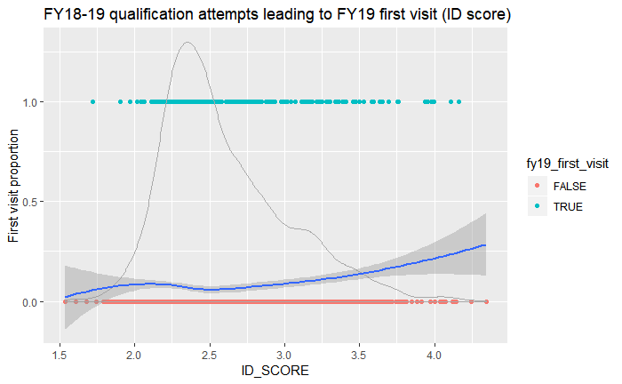

```r
visits_first_potential %>%
  # Remove ID_SCORE above 4.5
  filter(ID_SCORE < 4.5) %>%
  # Only people with qualification attempts in the last couple years
  filter(qual_EXCL_VISIT | outreach) %>%
  ggplot(aes(x = ID_SCORE)) +
  geom_point(aes(color = fy19_first_visit, y = as.numeric(fy19_first_visit))) +
  geom_density(color = 'darkgray') +
  geom_smooth(aes(y = as.numeric(fy19_first_visit)), method = 'loess') +
  labs(y = 'First visit proportion', title = 'FY18-19 qualification attempts leading to FY19 first visit (ID score)')
```

That’s a pretty compelling demonstration. Past 2.5 a higher ID_SCORE is pretty much linearly associated with a higher proportion of successful visits.

# PR and ID score metrics

Some summary statistics for each score.

```r
visits_first_potential %>%
  filter(qual_EXCL_VISIT | outreach) %>%
  select(PR_SCORE, ID_SCORE) %>%
  summary()
```

```
    PR_SCORE           ID_SCORE
 Min.   :0.000134   Min.   :1.536
 1st Qu.:0.077428   1st Qu.:2.302
 Median :0.260309   Median :2.494
 Mean   :0.813762   Mean   :2.599
 3rd Qu.:1.435675   3rd Qu.:2.832
 Max.   :4.040286   Max.   :4.684
```

```r
binned_scores <- visits_first_potential %>% mutate(
  # Truncate in .5 increments
  PR_bin = trunc(PR_SCORE / .5) * .5
    , ID_bin = trunc(ID_SCORE / .5) * .5
)
```

Looking at the same population of potential first-time visits:

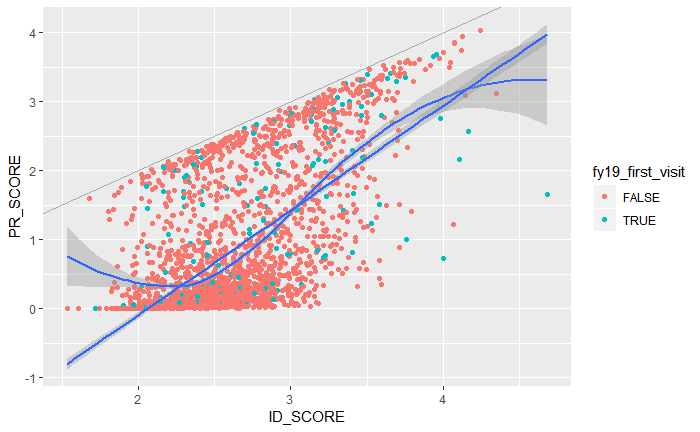

```r
binned_scores %>%
  filter(qual_EXCL_VISIT | outreach) %>%
  ggplot(aes(x = ID_SCORE, y = PR_SCORE)) +
  geom_point(aes(color = fy19_first_visit)) +
  geom_smooth(method = 'loess') +
  geom_smooth(method = 'lm') +
  geom_abline(slope = 1, intercept = 0, color = 'darkgray')
```

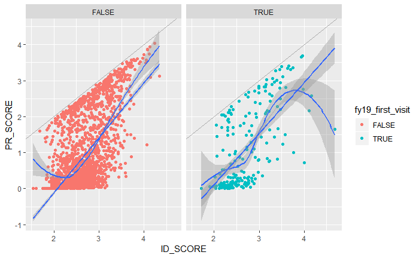

```r
binned_scores %>%
  filter(qual_EXCL_VISIT | outreach) %>%
  ggplot(aes(x = ID_SCORE, y = PR_SCORE)) +
  geom_point(aes(color = fy19_first_visit)) +
  geom_smooth(method = 'loess') +
  geom_smooth(method = 'lm') +
  geom_abline(slope = 1, intercept = 0, color = 'darkgray') +
  facet_grid(. ~ fy19_first_visit)
```

Binned:

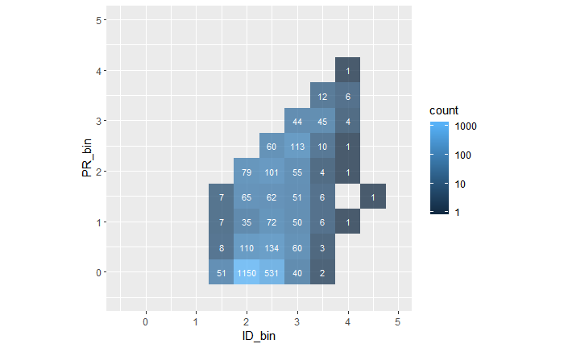

```r
binned_scores %>%
  filter(qual_EXCL_VISIT | outreach) %>%
  group_by(PR_bin, ID_bin) %>%
  summarise(n = length(ID_NUMBER)) %>%
  ggplot(aes(x = ID_bin, y = PR_bin, fill = n)) +
  geom_tile(alpha = .75) +
  geom_text(aes(label = n), color = 'white', size = 3) +
  coord_equal() +
  xlim(c(-.5, 5)) +
  ylim(c(-.5, 5)) +
  scale_fill_gradient(name = 'count', trans = 'log10')
```

My basic takeaway is that the ID score is by far the best predictor of whether someone will take a visit, doing a much better job than any other variable in isolation (the “Excel sort” standard practice). ID scores above 2.5 or so start looking promising. However, we still need to think about whether taking a visit or expected gift value is the right metric.